# Module 1 By Brian Weinfeld

**Principles of Data Visualization and Introduction to ggplot2**

I have provided you with data about the 5,000 fastest growing companies in the US, as compiled by Inc. magazine. lets read this in:

```r
inc <- read.csv("https://raw.githubusercontent.com/charleyferrari/CUNY_DATA_608/master/module1/Data/inc5000_data.csv", header= TRUE)
```

And lets preview this data:

```r
head(inc)
```

|  | Rank | Name | Growth_Rate | Revenue | Industry | Employees | City | State |
| --- | --- | --- | --- | --- | --- | --- | --- | --- |
| 1 | 1 | Fuhu | 421.48 | 1.179e+08 | Consumer Products & Services | 104 | El Segundo | CA |
| 2 | 2 | FederalConference.com | 248.31 | 4.960e+07 | Government Services | 51 | Dumfries | VA |
| 3 | 3 | The HCI Group | 245.45 | 2.550e+07 | Health | 132 | Jacksonville | FL |
| 4 | 4 | Bridger | 233.08 | 1.900e+09 | Energy | 50 | Addison | TX |
| 5 | 5 | DataXu | 213.37 | 8.700e+07 | Advertising & Marketing | 220 | Boston | MA |
| 6 | 6 | MileStone Community Builders | 179.38 | 4.570e+07 | Real Estate | 63 | Austin | TX |

```r
summary(inc)
```

```
      Rank                                     Name       Growth_Rate         Revenue                                  Industry      Employees
 Min.   :   1   110 Consulting                   :   1   Min.   :  0.340   Min.   :2.000e+06   IT Services                 : 733   Min.   :    1.0
 1st Qu.:1252   11thStreetCoffee.com             :   1   1st Qu.:  0.770   1st Qu.:5.100e+06   Business Products & Services: 482   1st Qu.:   25.0
 Median :2502   123 Exteriors                    :   1   Median :  1.420   Median :1.090e+07   Advertising & Marketing     : 471   Median :   53.0
 Mean   :2502   1st American Systems and Services:   1   Mean   :  4.612   Mean   :4.822e+07   Health                      : 355   Mean   :  232.7
 3rd Qu.:3751   1st Equity                       :   1   3rd Qu.:  3.290   3rd Qu.:2.860e+07   Software                    : 342   3rd Qu.:  132.0
 Max.   :5000   1-Stop Translation USA           :   1   Max.   :421.480   Max.   :1.010e+10   Financial Services          : 260   Max.   :66803.0
                (Other)                          :4995                                         (Other)                     :2358   NA's   :12
            City          State
 New York     : 160   CA     : 701
 Chicago      :  90   TX     : 387
 Austin       :  88   NY     : 311
 Houston      :  76   VA     : 283
 San Francisco:  75   FL     : 282
 Atlanta      :  74   IL     : 273
 (Other)      :4438   (Other):2764
```

Think a bit on what these summaries mean. Use the space below to add some more relevant non-visual exploratory information you think helps you understand this data:

```r
library(tidyverse)
inc %>%
  filter(complete.cases(.)) %>%
  group_by(Industry) %>%
  summarise(count = n(),
            min = min(Employees),
            avg = mean(Employees),
            med = median(Employees),
            max = max(Employees)) %>%
  arrange(desc(med))
```

| Industry | count | min | avg | med | max |
| --- | --- | --- | --- | --- | --- |
| Security | 73 | 7 | 562.45205 | 77.0 | 20000 |
| Human Resources | 196 | 4 | 1158.06122 | 71.5 | 66803 |
| Government Services | 202 | 6 | 129.62871 | 71.0 | 1352 |
| Health | 354 | 2 | 232.85311 | 71.0 | 4390 |
| Energy | 109 | 2 | 242.54128 | 70.0 | 2501 |
| Financial Services | 260 | 5 | 183.43462 | 70.0 | 1829 |
| Software | 341 | 1 | 150.32845 | 69.0 | 3000 |
| Environmental Services | 51 | 4 | 199.11765 | 67.0 | 5347 |
| Food & Beverage | 129 | 3 | 510.93798 | 65.0 | 7681 |
| Telecommunications | 127 | 6 | 242.85039 | 65.0 | 10000 |

[output cut: 15 more lines]

```r
inc %>%
  group_by(State) %>%
  summarise(Cities = n_distinct(City)) %>%
  arrange(desc(Cities))
```

| State | Cities |
| --- | --- |
| CA | 204 |
| IL | 104 |
| FL | 102 |
| NJ | 97 |
| NY | 90 |
| PA | 80 |
| OH | 79 |
| MA | 72 |
| TX | 67 |
| VA | 56 |

[output cut: 42 more lines]

```r
inc %>%
  filter(complete.cases(.)) %>%
  group_by(Industry) %>%
  summarise(count = n(),
            min = min(Growth_Rate),
            avg = mean(Growth_Rate),
            med = median(Growth_Rate),
            max = max(Growth_Rate)) %>%
  arrange(desc(med))
```

| Industry | count | min | avg | med | max |
| --- | --- | --- | --- | --- | --- |
| Government Services | 202 | 0.35 | 7.238168 | 2.110 | 248.31 |
| Energy | 109 | 0.35 | 9.603303 | 2.080 | 233.08 |
| Real Estate | 95 | 0.35 | 7.823158 | 2.080 | 179.38 |
| Media | 54 | 0.41 | 4.374074 | 1.940 | 23.01 |
| Consumer Products & Services | 203 | 0.35 | 8.776108 | 1.820 | 421.48 |
| Retail | 203 | 0.34 | 6.184729 | 1.760 | 166.89 |
| Software | 341 | 0.35 | 5.028446 | 1.700 | 128.63 |
| Advertising & Marketing | 471 | 0.35 | 6.225478 | 1.610 | 213.37 |
| Health | 354 | 0.35 | 4.868305 | 1.570 | 245.45 |
| Security | 73 | 0.37 | 3.388904 | 1.540 | 31.16 |

[output cut: 15 more lines]

```r
temp <- inc %>%
  filter(complete.cases(.))
cor(temp$Employees, temp$Growth_Rate)
```

```
[1] -0.0178689
```

## Question 1

Create a graph that shows the distribution of companies in the dataset by State (ie how many are in each state). There are a lot of States, so consider which axis you should use. This visualization is ultimately going to be consumed on a ‘portrait’ oriented screen (ie taller than wide), which should further guide your layout choices.

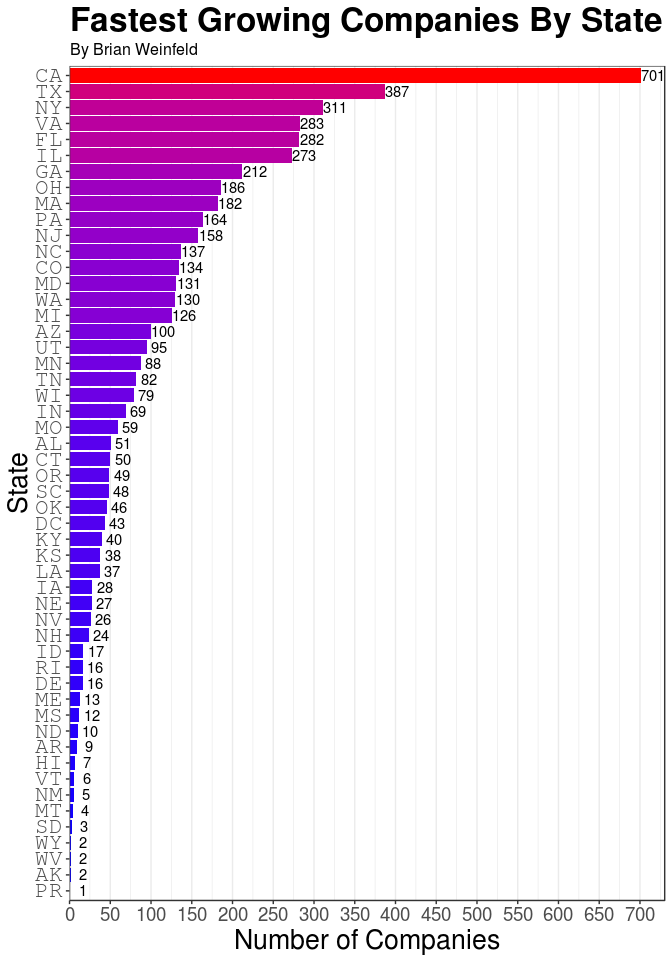

```r
inc %>%
  group_by(State) %>%
  count() %>%
  ggplot(aes(reorder(State, n), n)) +
  geom_bar(aes(fill=n), stat='identity', show.legend = FALSE) +
  geom_text(aes(y = n + 15, label=n)) +
  coord_flip() +
  scale_fill_continuous(low='blue', high='red') +
  scale_y_continuous(expand = c(0, 0, .02, .02), labels=seq(0, 800, 50), breaks = seq(0, 800, 50)) +
  theme_bw() +
  theme(panel.grid.major.y = element_blank(),
        axis.text.y = element_text(size=17, family='mono'),
        axis.text.x = element_text(size=14),
        axis.title = element_text(size=20),
        plot.title = element_text(size=25, face='bold'),
        plot.subtitle = element_text(size=12)) +
  labs(title = 'Fastest Growing Companies By State',
       subtitle = 'By Brian Weinfeld',
       y = 'Number of Companies',
       x = 'State')
```

## Question 2

Lets dig in on the state with the 3rd most companies in the data set. Imagine you work for the state and are interested in how many people are employed by companies in different industries. Create a plot that shows the average and/or median employment by industry for companies in this state (only use cases with full data, use R’s `complete.cases()` function.) In addition to this, your graph should show how variable the ranges are, and you should deal with outliers.

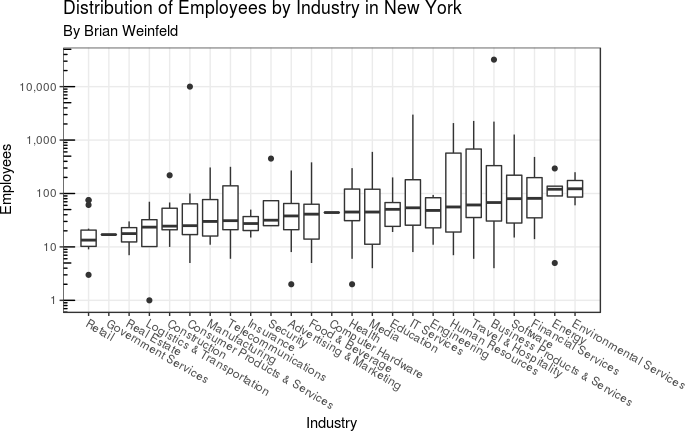

```r
inc %>%
  filter(complete.cases(.),
         State == 'NY') %>%
  ggplot(aes(reorder(Industry, Employees, FUN=median), Employees)) +
  geom_boxplot() +
  scale_y_log10(labels = scales::comma) +
  scale_x_discrete(expand = c(0.05, 0.05, 0.05, 0.05)) +
  annotation_logticks(sides = 'l') +
  theme_bw() +
  theme(axis.text.x = element_text(angle = -30, vjust = 1, hjust = 0),
        panel.grid.minor.y = element_blank(),
        plot.margin = margin(0, 75, 0, 0)) +
  labs(title = 'Distribution of Employees by Industry in New York',
       subtitle = 'By Brian Weinfeld',
       x = 'Industry')
```

## Question 3

Now imagine you work for an investor and want to see which industries generate the most revenue per employee. Create a chart that makes this information clear. Once again, the distribution per industry should be shown.

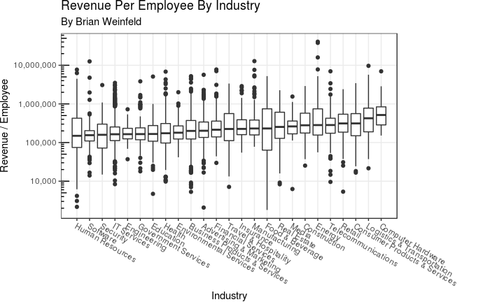

```r
inc %>%
  filter(!is.na(Revenue),
         !is.na(Employees)) %>%
  transform(Per = Revenue / Employees) %>%
  ggplot(aes(reorder(Industry, Per, FUN=median), Per)) +
  geom_boxplot() +
  scale_y_log10(labels = scales::comma) +
  scale_x_discrete(expand = c(.05, .05, .05, .05)) +
  annotation_logticks(sides='l') +
  theme_bw() +
  theme(axis.text.x = element_text(angle = -30, vjust = 1, hjust = 0),
        panel.grid.minor.y = element_blank(),
        plot.margin = margin(0, 100, 0, 0)) +
  labs(title = 'Revenue Per Employee By Industry',
       subtitle = 'By Brian Weinfeld',
       x = 'Industry',
       y = 'Revenue / Employee')
```